# Introduction to the Tidyverse: UN Data - Bonus

```r
districts |>
  filter(region == 'Mid Cumberland') |>
  arrange(desc(act_composite)) |>
  head(1)
```

| system | system_name | alg_1 | alg_2 | bio | chem | ela | eng_1 | eng_2 | eng_3 | math | science | enrollment | black | hispanic | native | el | swd | ed | expenditures | act_composite | chronic_abs | suspended | expelled | grad | dropout | region |
| --- | --- | --- | --- | --- | --- | --- | --- | --- | --- | --- | --- | --- | --- | --- | --- | --- | --- | --- | --- | --- | --- | --- | --- | --- | --- | --- |
| 940 | Williamson County | 90.3 | 84.8 | 89.2 | 81 | 80.7 | 92.9 | 88.7 | 68.6 | 80.3 | 91.1 | 34395 | 5 | 5.3 | 0.7 | 1.7 | 10.2 | 9.6 | 8739.7 | 23.8 | 7 | 0.2 | 0 | 94.4 | 4.4 | Mid Cumberland |

7. Create a scatter plot to compare alg_1 proficiency rates to alg_2 rates. What do you notice? Facet this plot by region. Does anything stand out when you facet the plots?

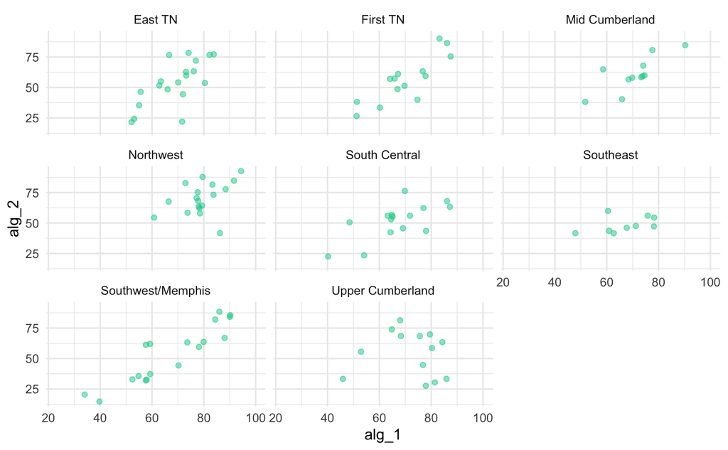

```r
ggplot(districts, aes(x=alg_1, y=alg_2))+
  geom_point(color='#00CC96', alpha=0.5) +
  facet_wrap(~region)+
  theme_minimal()
```

```r
districts |>
  summarize(sum(is.na(enrollment)))
```

| sum(is.na(enrollment)) |
| --- |
| 4 |

9. A lot of rows are missing additional values. Which district has the largest number of missing values (across all variables)? Hint: you might want to look at rowwise and c_across to answer this question.

```r
districts |>
  rowwise() |>
  mutate(missing_vals = sum(is.na(c_across(alg_1:dropout)))) |>
  arrange(desc(missing_vals)) |>
  head(2)
```

| system | system_name | alg_1 | alg_2 | bio | chem | ela | eng_1 | eng_2 | eng_3 | math | science | enrollment | black | hispanic | native | el | swd | ed | expenditures | act_composite | chronic_abs | suspended | expelled | grad | dropout | region | missing_vals |
| --- | --- | --- | --- | --- | --- | --- | --- | --- | --- | --- | --- | --- | --- | --- | --- | --- | --- | --- | --- | --- | --- | --- | --- | --- | --- | --- | --- |
| 960 | West Tenn School for Deaf | NA | NA | NA | NA | NA | NA | NA | NA | NA | NA | NA | 48.7 | 7.7 | 0.0 | 0 | 97.4 | 76.9 | NA | NA | 23.1 | 0.0 | 0 | NA | NA | Southwest/Memphis | 15 |
| 11 | Clinton City | NA | NA | NA | NA | 58.3 | NA | NA | NA | 68.9 | 69.6 | 894 | 5.7 | 2.8 | 0.3 | 1 | 18.1 | 63.4 | 9537.5 | NA | 8.8 | 1.2 | 0 | NA | NA | East TN | 10 |

10. What is the mean graduation rate across all districts? What might be wrong with using just the regular mean to assess average graduation rates?

```r
districts |>
  drop_na(grad) |>
  summarise(mean(grad))
```

| mean(grad) |
| --- |
| 90.06562 |

The simple mean counts all district entries equally when tallying scores, but using the weighted mean would give some schools less of an impact and others more of an impact on the overall mean. Districts should have a weight proportional to their enrollment.

11. Redo the previous question but use a weighted average (`weighted.mean`) graduation across all districts, weighing by enrollment. How much does this change your answer? Can you explain using the data the reason for the big change from using the mean?

```r
districts |>
  drop_na(c(grad, enrollment)) |>
  summarise(weighted.mean(grad, enrollment))
```

| weighted.mean(grad, enrollment) |
| --- |
| 87.33285 |

12. Find the unweighted and weighted average graduation rate by region.

```r
regional_grad_rates <- districts |>
  drop_na(grad, enrollment) |>
  group_by(region) |>
  summarize(mean = mean(grad), `weighted mean (by enrollment)`= weighted.mean(grad, enrollment))
regional_grad_rates
```

| region | mean | weighted mean (by enrollment) |
| --- | --- | --- |
| East TN | 91.48947 | 89.87089 |
| First TN | 92.57333 | 91.91454 |
| Mid Cumberland | 91.51667 | 88.53965 |
| Northwest | 91.31579 | 91.57705 |
| South Central | 91.01333 | 90.47392 |
| Southeast | 89.09091 | 85.95494 |
| Southwest/Memphis | 87.10556 | 79.45971 |
| Upper Cumberland | 92.81250 | 92.24062 |

```r
districts |>
  drop_na(grad, enrollment) |>
  group_by(region) |>
  mutate(weighted = weighted.mean(grad, enrollment))
```

| system | system_name | alg_1 | alg_2 | bio | chem | ela | eng_1 | eng_2 | eng_3 | math | science | enrollment | black | hispanic | native | el | swd | ed | expenditures | act_composite | chronic_abs | suspended | expelled | grad | dropout | region | weighted |
| --- | --- | --- | --- | --- | --- | --- | --- | --- | --- | --- | --- | --- | --- | --- | --- | --- | --- | --- | --- | --- | --- | --- | --- | --- | --- | --- | --- |
| 10 | Anderson County | 76.1 | 63.3 | 73.6 | 41.0 | 45.7 | 73.7 | 59.2 | 38.2 | 54.0 | 64.5 | 6304 | 2.8 | 1.1 | 0.5 | 0.2 | 18.0 | 58.5 | 9535.7 | 19.9 | 11.5 | 5.0 | 0.1 | 94.0 | 4.2 | East TN | 89.87089 |
| 12 | Oak Ridge City | 76.9 | 72.0 | 83.5 | 80.9 | 56.1 | 86.7 | 74.6 | 53.8 | 55.3 | 70.8 | 4326 | 16.6 | 8.0 | 0.7 | 3.0 | 14.3 | 52.5 | 12355.5 | 23.1 | 17.5 | 5.7 | 0.0 | 89.7 | 4.4 | East TN | 89.87089 |
| 20 | Bedford County | 64.3 | 42.4 | 62.1 | 32.5 | 44.1 | 72.3 | 63.1 | 44.6 | 53.1 | 61.8 | 8270 | 11.2 | 20.6 | 0.5 | 9.4 | 10.9 | 69.9 | 7756.2 | 18.4 | 8.6 | 2.2 | 0.0 | 90.8 | 5.4 | South Central | 90.47392 |
| 30 | Benton County | 73.7 | 58.4 | 77.1 | 33.1 | 46.0 | 75.4 | 60.8 | 45.6 | 53.9 | 65.0 | 2133 | 3.9 | 2.1 | 0.3 | 0.0 | 18.8 | 50.2 | 9714.2 | 18.4 | 6.5 | 0.0 | 0.0 | 94.5 | 3.0 | Northwest | 91.57705 |
| 40 | Bledsoe County | 64.8 | 73.9 | 73.0 | 19.5 | 35.4 | 63.6 | 53.3 | 50.0 | 41.1 | 56.2 | 1674 | 1.5 | 6.8 | 0.6 | 2.3 | 19.7 | 83.5 | 9495.9 | 19.2 | 9.1 | 2.4 | 0.1 | 92.4 | 6.9 | Upper Cumberland | 92.24062 |
| 50 | Blount County | 73.2 | 59.8 | 65.1 | 45.4 | 46.3 | 71.8 | 66.0 | 45.3 | 50.5 | 68.4 | 10500 | 3.0 | 4.2 | 0.4 | 1.9 | 12.8 | 54.2 | 8866.9 | 19.7 | 17.0 | 4.7 | 0.1 | 89.1 | 9.2 | East TN | 89.87089 |
| 51 | Alcoa City | 82.2 | 76.8 | 88.0 | 66.0 | 50.2 | 85.5 | 79.6 | 67.2 | 56.6 | 65.1 | 1850 | 23.3 | 9.5 | 0.6 | 2.7 | 13.0 | 49.4 | 10320.0 | 22.0 | 4.7 | 3.1 | 0.1 | 98.2 | 0.9 | East TN | 89.87089 |
| 52 | Maryville City | 83.8 | 77.3 | 92.1 | 80.4 | 69.6 | 89.9 | 82.7 | 68.1 | 70.2 | 87.1 | 4944 | 4.2 | 4.0 | 0.2 | 2.8 | 13.2 | 32.1 | 10161.2 | 23.0 | 2.0 | 2.7 | 0.0 | 96.6 | 3.1 | East TN | 89.87089 |
| 60 | Bradley County | NA | 59.5 | 64.1 | 55.7 | 52.4 | 74.4 | 66.3 | 38.2 | 57.1 | 65.9 | 9801 | 3.6 | 4.3 | 0.3 | 1.6 | 11.3 | 55.1 | 8429.3 | 18.8 | 16.0 | 3.9 | 0.1 | 93.1 | 5.6 | Southeast | 85.95494 |
| 61 | Cleveland City | 62.7 | 41.6 | 51.0 | 47.3 | 46.0 | 71.0 | 61.3 | 48.7 | 51.4 | 58.9 | 5184 | 15.0 | 18.8 | 0.3 | 8.2 | 14.4 | 69.5 | 9239.2 | 18.9 | 15.3 | 7.0 | 0.0 | 84.1 | 12.3 | Southeast | 85.95494 |

[output cut: 115 more lines]

**Continued Exploration and Practice**

13. Read in the school-level testing data for 2014, available [here](https://www.tn.gov/content/dam/tn/education/data/data_2014_state_base.xlsx). You might find the readxl library useful for this task. If you use this library, be sure to look at the `na` argument for the `read_excel` function.

```r
library(readxl)

school_testing = read_excel('../data/tn_state_data.xlsx', na="NA")
school_testing
```

| year | system | system_name | school | school_name | subject | grade | subgroup | valid_tests | n_below_bsc | n_bsc | n_prof | n_adv | pct_below_bsc | pct_bsc | pct_prof | pct_adv | pct_bsc_and_below | pct_prof_adv |
| --- | --- | --- | --- | --- | --- | --- | --- | --- | --- | --- | --- | --- | --- | --- | --- | --- | --- | --- |
| 2014 | 10 | Anderson County | 2 | Anderson County High School | Algebra I | All Grades | All Students | 225 | 15 | 39 | 79 | 92 | 6.7 | 17.3 | 35.1 | 40.9 | 24 | 76 |
| 2014 | 10 | Anderson County | 2 | Anderson County High School | Algebra I | All Grades | White | 222 | 13 | 39 | 79 | 91 | 5.8 | 17.600000000000001 | 35.6 | 41 | 23.4 | 76.599999999999994 |
| 2014 | 10 | Anderson County | 2 | Anderson County High School | Algebra I | All Grades | Black | 1 | * | * | * | * | * | * | * | * | * | * |
| 2014 | 10 | Anderson County | 2 | Anderson County High School | Algebra I | All Grades | Asian | 1 | * | * | * | * | * | * | * | * | * | * |
| 2014 | 10 | Anderson County | 2 | Anderson County High School | Algebra I | All Grades | Native American | 1 | * | * | * | * | * | * | * | * | * | * |
| 2014 | 10 | Anderson County | 2 | Anderson County High School | Algebra I | All Grades | Economically Disadvantaged | 116 | 12 | 26 | 43 | 35 | 10.3 | 22.4 | 37.1 | 30.2 | 32.700000000000003 | 67.3 |
| 2014 | 10 | Anderson County | 2 | Anderson County High School | Algebra I | All Grades | Students with Disabilities | 35 | 9 | 12 | 9 | 5 | 25.7 | 34.299999999999997 | 25.7 | 14.3 | 60 | 40 |
| 2014 | 10 | Anderson County | 2 | Anderson County High School | Algebra I | All Grades | Black/Hispanic/Native American | 2 | * | * | * | * | * | * | * | * | * | * |
| 2014 | 10 | Anderson County | 2 | Anderson County High School | Algebra I | All Grades | Non-Economically Disadvantaged | 109 | 3 | 13 | 36 | 57 | 2.8 | 11.9 | 33 | 52.3 | 14.7 | 85.3 |
| 2014 | 10 | Anderson County | 2 | Anderson County High School | Algebra I | All Grades | Non-Students with Disabilities | 190 | 6 | 27 | 70 | 87 | 3.2 | 14.2 | 36.799999999999997 | 45.8 | 17.399999999999999 | 82.6 |

[output cut: 990 more lines]

To answer the following questions, use “All Students” for the subgroup.

```r
school_testing <- school_testing |>
  filter(subgroup=='All Students') |>
  mutate_at(vars(n_below_bsc:pct_prof_adv), as.numeric)
school_testing
```

| year | system | system_name | school | school_name | subject | grade | subgroup | valid_tests | n_below_bsc | n_bsc | n_prof | n_adv | pct_below_bsc | pct_bsc | pct_prof | pct_adv | pct_bsc_and_below | pct_prof_adv |
| --- | --- | --- | --- | --- | --- | --- | --- | --- | --- | --- | --- | --- | --- | --- | --- | --- | --- | --- |
| 2014 | 10 | Anderson County | 2 | Anderson County High School | Algebra I | All Grades | All Students | 225 | 15 | 39 | 79 | 92 | 6.7 | 17.3 | 35.1 | 40.9 | 24.0 | 76.0 |
| 2014 | 10 | Anderson County | 2 | Anderson County High School | Algebra I | 9 | All Students | 184 | NA | NA | NA | NA | NA | NA | NA | NA | 12.5 | 87.5 |
| 2014 | 10 | Anderson County | 2 | Anderson County High School | Algebra I | 10 | All Students | 39 | 13 | 17 | 8 | 1 | 33.3 | 43.6 | 20.5 | 2.6 | 76.9 | 23.1 |
| 2014 | 10 | Anderson County | 2 | Anderson County High School | Algebra I | 11 | All Students | 1 | NA | NA | NA | NA | NA | NA | NA | NA | NA | NA |
| 2014 | 10 | Anderson County | 2 | Anderson County High School | Algebra I | 12 | All Students | 1 | NA | NA | NA | NA | NA | NA | NA | NA | NA | NA |
| 2014 | 10 | Anderson County | 2 | Anderson County High School | Algebra II | All Grades | All Students | 238 | 50 | 74 | 63 | 51 | 21.0 | 31.1 | 26.5 | 21.4 | 52.1 | 47.9 |
| 2014 | 10 | Anderson County | 2 | Anderson County High School | Algebra II | 10 | All Students | 59 | NA | NA | NA | NA | NA | NA | NA | NA | 0.0 | 100.0 |
| 2014 | 10 | Anderson County | 2 | Anderson County High School | Algebra II | 11 | All Students | 172 | 45 | 72 | 51 | 4 | 26.1 | 41.9 | 29.7 | 2.3 | 68.0 | 32.0 |
| 2014 | 10 | Anderson County | 2 | Anderson County High School | Algebra II | 12 | All Students | 7 | NA | NA | NA | NA | NA | NA | NA | NA | NA | NA |
| 2014 | 10 | Anderson County | 2 | Anderson County High School | English I | All Grades | All Students | 269 | 11 | 56 | 174 | 28 | 4.1 | 20.8 | 64.7 | 10.4 | 24.9 | 75.1 |

[output cut: 990 more lines]

```r
school_testing |>
  distinct(school_name) |>
  count()
```

| n |
| --- |
| 1607 |

14. How many schools have at least 20 percent of students below bsc for Algebra I? Which districts do these schools belong to?

```r
# subject = Algebra I
alg_1_sub_20 <- school_testing |>
  filter(subject=='Algebra I' & pct_below_bsc >=20)

alg_1_sub_20 |>
  count()
```

| n |
| --- |
| 239 |

```r
alg_1_sub_20 |>
  distinct(system_name)
```

| system_name |
| --- |
| Anderson County |
| Oak Ridge |
| Bedford County |
| Bledsoe County |
| Blount County |
| Maryville |
| Bradley County |
| Campbell County |
| Hollow Rock-Bruceton |
| Carter County |

[output cut: 64 more lines]

```r
school_testing |>
  filter((subject=='Algebra I' | subject=='English I') & pct_below_bsc >=20) |>
  count()
```

| n |
| --- |
| 255 |

16. Which grade has the highest pct_adv for Algebra I? Plot the average pct_adv per grade level as a bar chart. Make sure that the bars are ordered by grade level.

```r
max_pct_adv <-school_testing |>
  filter(subject=='Algebra I' & grade != 'All Grades') |>
  drop_na(pct_adv) |>
  group_by(grade) |>
  summarise(pct_adv_max = max(pct_adv)) |>
  arrange(desc(pct_adv_max)) |>
  head(1)
max_pct_adv
```

| grade | pct_adv_max |
| --- | --- |
| 8 | 88.9 |

```r
avg_pct_adv <- school_testing |>
  filter(subject=='Algebra I' & grade != 'All Grades') |>
  mutate(grade = as.numeric(grade)) |>
  drop_na(pct_adv) |>
  group_by(grade) |>
  summarise(pct_adv_mean = mean(pct_adv, na.rm = TRUE)) |>
  mutate(across(c('grade', 'pct_adv_mean'), round, 2)) |>
  arrange(grade)
avg_pct_adv
```

| grade | pct_adv_mean |
| --- | --- |
| 8 | 35.52 |
| 9 | 32.87 |
| 10 | 8.05 |
| 11 | 14.10 |
| 12 | 16.70 |

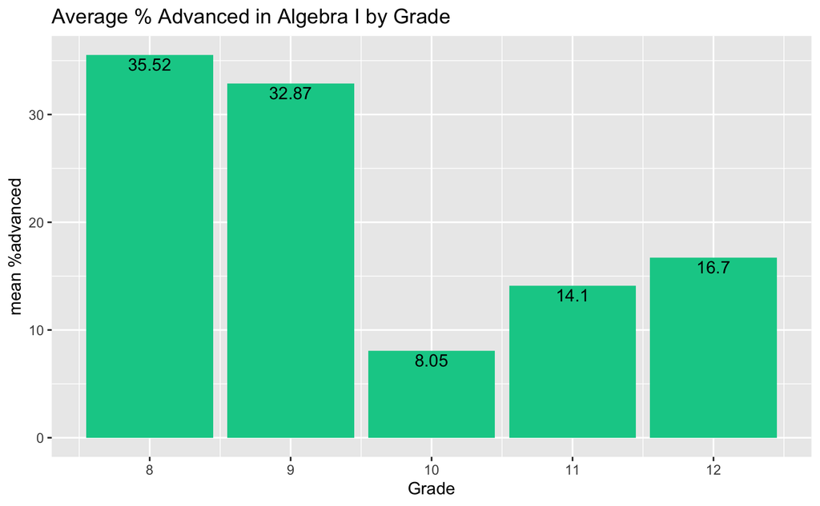

```r
ggplot(avg_pct_adv, aes(x=grade, y=pct_adv_mean)) +
  geom_col(fill='#00CC96')+
  labs(title = 'Average % Advanced in Algebra I by Grade',
       x='Grade',
       y='mean %advanced')+
  geom_text(aes(label = pct_adv_mean), vjust = 1.25)
```

17. Find the correlation between pct_adv for Algebra I and pct_adv for Algebra II by school. Create a scatterplot showing Algebra II scores vs. Algebra I scores by school.

```r
school_testing |>
  filter(subject %in% c('Algebra I', 'Algebra II'), school_name == 'Bailey STEM Magnet Middle')
```

| year | system | system_name | school | school_name | subject | grade | subgroup | valid_tests | n_below_bsc | n_bsc | n_prof | n_adv | pct_below_bsc | pct_bsc | pct_prof | pct_adv | pct_bsc_and_below | pct_prof_adv |
| --- | --- | --- | --- | --- | --- | --- | --- | --- | --- | --- | --- | --- | --- | --- | --- | --- | --- | --- |
| 2014 | 190 | Davidson County | 30 | Bailey STEM Magnet Middle | Algebra I | All Grades | All Students | 26 | 1 | 10 | 11 | 4 | 3.8 | 38.5 | 42.3 | 15.4 | 42.3 | 57.7 |
| 2014 | 190 | Davidson County | 30 | Bailey STEM Magnet Middle | Algebra I | 8 | All Students | 26 | 1 | 10 | 11 | 4 | 3.8 | 38.5 | 42.3 | 15.4 | 42.3 | 57.7 |

```r
# Remove rows with missing `pct_adv` and limit to relevant subjects
algebras_cleaned <- school_testing |>
  filter(subject %in% c("Algebra I", "Algebra II")) |>
  drop_na(pct_adv) |>
  group_by(school_name, subject) |>
  summarise(pct_adv = mean(pct_adv, na.rm = TRUE), .groups = "drop") # Resolve duplicates
algebras_cleaned
```

| school_name | subject | pct_adv |
| --- | --- | --- |
| Adamsville Junior/Senior High School | Algebra I | 37.500000 |
| Adamsville Junior/Senior High School | Algebra II | 7.850000 |
| Alcoa High School | Algebra I | 32.850000 |
| Alcoa High School | Algebra II | 12.500000 |
| Alvin C. York Institute | Algebra I | 36.900000 |
| Alvin C. York Institute | Algebra II | 25.033333 |
| Anderson County High School | Algebra I | 21.750000 |
| Anderson County High School | Algebra II | 11.850000 |
| Antioch High School | Algebra I | 24.000000 |
| Antioch High School | Algebra II | 5.900000 |

[output cut: 612 more lines]